# Replicating Hayley’s RTS,S & SMC report results

Hillary Topazian

20 October 2021

```r
# packages
library(tidyverse)
library(fuzzyjoin)
library(cowplot)
library(plotly)
library(kableExtra)
library(malariasimulation)
library(data.table)

library(patchwork)
library(scales)
library(LaCroixColoR)

# devtools::install_github('mrc-ide/malariasimulation@dev', force=TRUE)
# devtools::install_github('johannesbjork/LaCroixColoR')
knitr::opts_knit$set(message=FALSE, warning=FALSE)
```

# Set-up

Our goal here is to compare model outputs from `malariasimulation` to `MalariaLanchR`, and to replicate Hayley’s findings from her report.

I have checked -

- **Seasonality**
  - High seasonality - g0 = 0.284596, g = c(-0.317878, -0.0017527, 0.116455), h = c(-0.331361, 0.293128, -0.0617547)
  - Low seasonality - g0 = 0.285505, g = c(-0.325352, -0.0109352, 0.0779865), h = c(-0.132815, 0.104675, -0.013919)
  - seasonal intervention efficacy starts at 4 months for seasonal settings and 6 months for highly seasonal settings.
- **Human population** = 100,000. Average_age = 8453.323.
- **Warmup** = 20 years for malariasimulation to stabilize at EIR equilibrium
- **Simulation length** = 15 years
- **Species** = 25% arabiensis, 25% funestus, 50% gambiae. Bednet and indoor parameters checked and match. No info for IRS parameters since intervention is not turned on.
- **Treatment**
  - drug = AL
  - drug_efficacy = 0.95000
  - drug_rel_c = 0.05094
  - drug_prophylaxis_shape = 11.30000
  - drug_prophylaxis_scale = 10.60000
  - coverage = 0.45
- **RTS,S**
  - boosters: given 12 months after dose 3 (booster 1) and 24 months after dose 3 (booster 2)
  - booster coverage = 0.80
  - boosted antibody mean and stdev = 5.56277, 0.35
  - updated antibody mean and stdev = 6.37008, 0.35 (and synergy)
  - for synergy model: rtss_vmax = 0.911028, rtss_alpha = 0.75303, rtss_beta = 62.8525
- **SMC**
  - drug = SP-AQ
  - drug_efficacy = 0.75
  - drug_rel_c = 0.32
  - drug_prophylaxis_shape = 3.67 (modified from default)
  - drug_prophylaxis_scale = 41.48 (modified from default)
  - coverage = 0.75
  - min-age = 3 months
  - max-age = 5 years
  - synergy drug_prophylaxis_shape = 2.955348
  - synergy drug_prophylaxis_scale = 58.99686
  - 4 monthly rounds, with timing based on seasonality cuves
- **Outcomes**
  - unless otherwise stated events averted are calculated relative to a baseline no-vaccination scenario
  - clinical incidence calculated among individuals 0-100 years
  - severe malaria enabled
  - fvt (reduced probability of death due to treatment) and v (mortality scaling factor from severe disease) set to 0
  - deaths - calculating deaths from severe disease use the following: mortality = 0.215 * severe incidence

# Link Pf prev 2-10 to EIR

`MalariaLanchR` accepts PfPR<sub>2-10</sub> values as inputs to set the model at an equilibrium value. But `malariasimulation` only accepts EIR value inputs using the function `set_equilibrium()`. We will use a range of `malariasimulation` outputs to back link PfPR<sub>2-10</sub> values to EIR outputs using `fuzzyjoin`. Separate matching processes must take place for each seasonality setting. Essentially, we set our baseline parameters, and then run multiple simulations at various EIRs using those baseline settings. We then create a best-fit line through these points, and match with PfPR<sub>2-10</sub>. The blue line in the following plots displays results from `malariaEquilibrium`, which end up underestimating the EIRs to be used in the model.

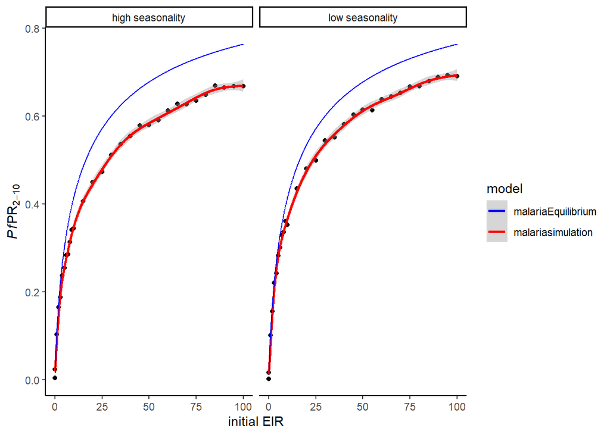

```r
# loop over malariasimulation runs
init_EIR <- c(0.01, 0.1, seq(1,9,1), seq(10, 100, by=5)) # set EIR values

# files ending in 2 are for individual_mosquitoes = F. No number is for individiaul_mosquitoes = T.
EIR_prev1 <- readRDS('C:/Users/htopazia/OneDrive - Imperial College London/Github/rtss_malariasimulation/rds/EIR_prev_high.rds') %>% mutate(season = 'high seasonality')

EIR_prev2 <- readRDS('C:/Users/htopazia/OneDrive - Imperial College London/Github/rtss_malariasimulation/rds/EIR_prev_low.rds') %>% mutate(season = 'low seasonality')

EIR_prev <- rbind(EIR_prev1, EIR_prev2)

# calculate EIR / prev 2-10 relationship from malariEquilibrium
eir <- seq(from = .1, to = 100, by=.1)
eq_params <- malariaEquilibrium::load_parameter_set("Jamie_parameters.rds")

prev <- vapply( # calculate prevalence between 2:10 for a bunch of EIRs
  eir,
  function(eir) {
    eq <- malariaEquilibrium::human_equilibrium(
      eir,
      ft=0,
      p=eq_params,
      age=0:100
    )
    sum(eq$states[2:10, 'pos_M']) / sum(eq$states[2:10, 'prop'])
  },
  numeric(1)
)

prevmatch <- as_tibble(cbind(eir,prev))

colors <- c("malariaEquilibrium" = "blue", "malariasimulation" = "red")


p <- ggplot(data=EIR_prev) +
  geom_point(aes(x=init_EIR, y=prev), color='black') +
  stat_smooth(aes(x=init_EIR, y=prev, color='malariasimulation'), method = 'gam', n=1000) +
  geom_line(data=prevmatch, aes(x=eir, y=prev, color = 'malariaEquilibrium')) +
  labs(x='initial EIR', y=expression(paste(italic(Pf),"PR"[2-10])), color='model') +
  facet_wrap('season', nrow=1) +
  scale_color_manual(values = colors) +
  theme_classic()

p
```

```r
# extract points from stat_smooth
p2 <- ggplot_build(p)
p2 <- p2$data[[2]]

p2 <- p2 %>% as_tibble() %>% select(x,y,PANEL) %>% rename(init_EIR=x, pred=y, season=PANEL) %>%
  mutate(season=ifelse(season==1,'high seasonality','low seasonality'))


# Pre-intervention baseline PfPR2-10 starting at values 10, 25, 35, 55
PfPR <- as_tibble_col(c(.10, .25, .35, .55), column_name="pfpr")

# match via stat_smooth predictions
match <- PfPR %>%
  fuzzyjoin::difference_left_join(p2, by=c("pfpr"="pred"),
                                  max_dist=1, distance_col="dist") %>%
  group_by(pfpr, season) %>% slice_min(dist) %>%
  rename(eir=init_EIR) %>%
  mutate(eir = as.numeric(round(eir,1)), seasonality=case_when(season=='high seasonality'~'highly_seasonal', TRUE~'seasonal')) %>% ungroup() %>% select(-season)

match
```

```
## # A tibble: 8 x 5
##    pfpr   eir   pred      dist seasonality
##   <dbl> <dbl>  <dbl>     <dbl> <chr>
## 1  0.1    1.1 0.0969 0.00309   highly_seasonal
## 2  0.1    1.2 0.104  0.00354   seasonal
## 3  0.25   4.7 0.250  0.000218  highly_seasonal
## 4  0.25   4   0.251  0.00148   seasonal
## 5  0.35  10.1 0.351  0.000623  highly_seasonal
## 6  0.35   8.7 0.350  0.000196  seasonal
## 7  0.55  38.2 0.550  0.0000110 highly_seasonal
## 8  0.55  32.6 0.550  0.000172  seasonal
```

EIR values are 1.1, 4.7, 10.1, and 38.2 in highly seasonal settings. EIR values are 1.2, 4.0, 8.7, and 32.6 in seasonal settings.

# Figure 1

From Hayley’s report:

> Figure 1 Cumulative clinical cases averted over 15 years as a function of baseline PfPR2-10 (four settings representative of medium to high transmission intensity are shown) and seasonality A&C) per population and B&D) per 100,000 fully vaccinated children. Coverage is fixed at 80% for the first three doses with a 20% drop off (from the 3rd dose) for the fourth and fifth doses (coverage is the same for the 4th and 5th dose). Fully vaccinated children are defined as those receiving the primary series (first three doses). EPI- is the four-dose age-based strategy, SV 4&5-dose is the seasonal strategy assuming the original vaccine efficacy profile from the Phase 3 RTS,S trials, SV 4&5-dose – updated booster is the seasonal strategy assuming the updated higher efficacy against infection for the 4th and 5th dose based on our validation to the seasonal malaria vaccination Phase 3b clinical trial (Annex 1).

## MalariaLaunchR

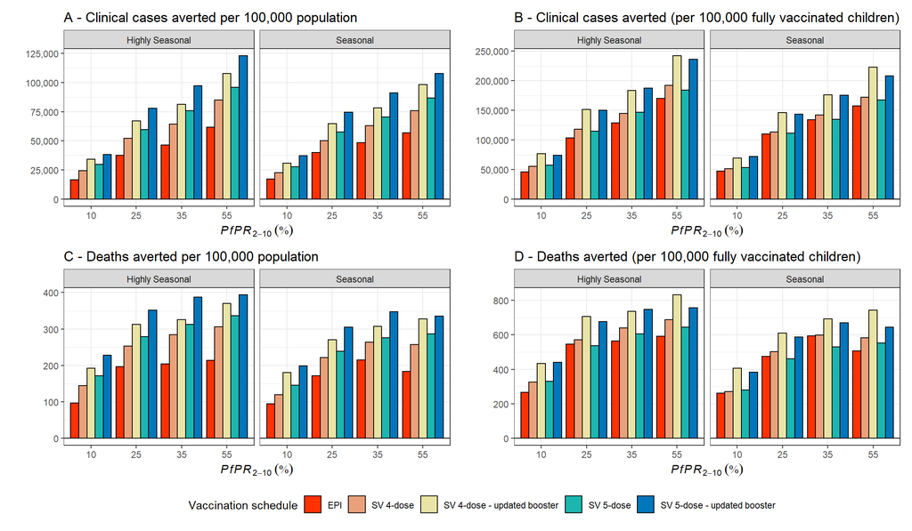

```r
impact <- readRDS('C:/Users/htopazia/OneDrive - Imperial College London/Github/Hayley_report/Part_1/impact_costs_all_ages.RDS')

#-New facet label names for sease variables--
seas.labs <- c("Highly Seasonal", "Seasonal")
names(seas.labs) <- c("highly_seasonal", "seasonal")

figure_2_pd <-
  impact %>%
  filter(coverage == 0.8, cost_per_dose == 6.52, delivery_cost == 1.62) %>%
  filter(pfpr %in% c(0.1,0.25,0.35,0.55))

#-per population----------------------------
ca <-
  ggplot(figure_2_pd, aes(x = factor(pfpr * 100), y = cases_averted, fill=run)) +
  geom_hline(yintercept = 0) +
  geom_bar(position=position_dodge(), stat="identity",colour="black") +
  scale_fill_manual(values=lacroix_palette("PeachPear"),
                    labels=c("epi" = "EPI",
                             "srtss_4_dose_original" = "SV 4-dose",
                             "srtss_5_dose_original" = "SV 5-dose",
                             "srtss_4_dose_update" = "SV 4-dose - updated booster",
                             "srtss_5_dose_update" = "SV 5-dose - updated booster"))+
  labs(x = expression(paste(italic(Pf),"PR"[2-10])),
       y = " ",
       fill="Vaccination schedule",
       parse=TRUE) +
  scale_y_continuous(labels = comma) +
  facet_wrap(seasonality  ~ ., labeller = labeller(seasonality = seas.labs)) +
  xlab(expression(italic(PfPR[2-10]~(symbol("\045"))))) +
  ggtitle("A - Clinical cases averted per 100,000 population") +
  theme_bw( )


#-per 100,000 fully vaccinated people----------
ca_fvp <-
  ggplot(figure_2_pd, aes(x = factor(pfpr * 100), y = cases_averted_per_100000_fvp, fill=run)) +
  geom_hline(yintercept = 0) +
  geom_bar(position=position_dodge(), stat="identity",colour="black") +
  scale_fill_manual(values=lacroix_palette("PeachPear"),
                    labels=c("epi" = "EPI",
                             "srtss_4_dose_original" = "SV 4-dose",
                             "srtss_5_dose_original" = "SV 5-dose",
                             "srtss_4_dose_update" = "SV 4-dose - updated booster",
                             "srtss_5_dose_update" = "SV 5-dose - updated booster"))+
  labs(x = expression(paste(italic(Pf),"PR"[2-10])),
       y = " ",
       fill="Vaccination schedule",
       parse=TRUE) +
  scale_y_continuous(labels = comma) +
  facet_wrap(seasonality  ~ ., labeller = labeller(seasonality = seas.labs)) +
 # ylab("Clinical cases averted\n(per 100,000 fully vaccinated children)") +
  xlab(expression(italic(PfPR[2-10]~(symbol("\045"))))) +
  ggtitle("B - Clinical cases averted (per 100,000 fully vaccinated children)") +
  theme_bw( )

#-deaths averted per population--------------
da <-
  ggplot(figure_2_pd, aes(x = factor(pfpr * 100), y = deaths_averted, fill=run)) +
  geom_hline(yintercept = 0) +
  geom_bar(position=position_dodge(), stat="identity",colour="black") +
  scale_fill_manual(values=lacroix_palette("PeachPear"),
                    labels=c("epi" = "EPI",
                             "srtss_4_dose_original" = "SV 4-dose",
                             "srtss_5_dose_original" = "SV 5-dose",
                             "srtss_4_dose_update" = "SV 4-dose - updated booster",
                             "srtss_5_dose_update" = "SV 5-dose - updated booster"))+
  labs(x = expression(paste(italic(Pf),"PR"[2-10])),
       y = " ",
       fill="Vaccination schedule",
       parse=TRUE) +
  scale_y_continuous(labels = comma) +
  facet_wrap(seasonality  ~ ., labeller = labeller(seasonality = seas.labs)) +
  xlab(expression(italic(PfPR[2-10]~(symbol("\045"))))) +
  ggtitle("C - Deaths averted per 100,000 population") +
  theme_bw( )

#-deaths averted per 100,000 fully vaccinated-------
da_fvp <-
  ggplot(figure_2_pd, aes(x = factor(pfpr * 100), y = deaths_averted_per_100000_fvp, fill=run)) +
  geom_hline(yintercept = 0) +
  geom_bar(position=position_dodge(), stat="identity",colour="black") +
  scale_fill_manual(values=lacroix_palette("PeachPear"),
                    labels=c("epi" = "EPI",
                             "srtss_4_dose_original" = "SV 4-dose",
                             "srtss_5_dose_original" = "SV 5-dose",
                             "srtss_4_dose_update" = "SV 4-dose - updated booster",
                             "srtss_5_dose_update" = "SV 5-dose - updated booster"))+
  labs(x = expression(paste(italic(Pf),"PR"[2-10])),
       y = " ",
       fill="Vaccination schedule",
       parse=TRUE) +
  scale_y_continuous(labels = comma) +
  facet_wrap(seasonality  ~ ., labeller = labeller(seasonality = seas.labs)) +
  xlab(expression(italic(PfPR[2-10]~(symbol("\045"))))) +
  ggtitle("D - Deaths averted (per 100,000 fully vaccinated children)") +
  theme_bw( )

#-combining outputs into single figure
main_fig <- ca + ca_fvp + da + da_fvp + plot_layout(guides = "collect") & theme(legend.position = "bottom")

main_fig
```

```r
# ggsave("combined_averted.png", main_fig, width=12, height = 7)
```

## malariasimulation

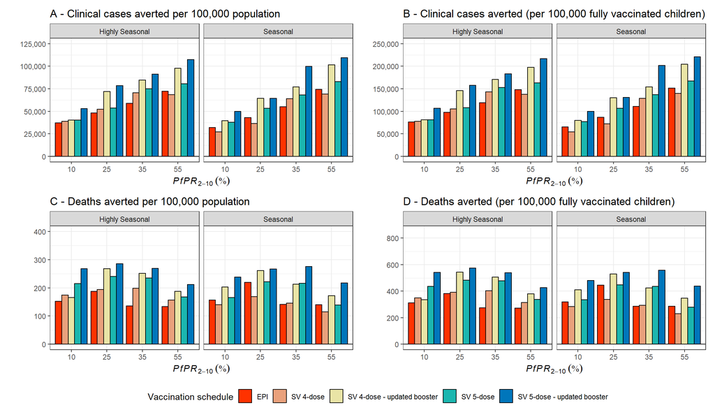

```r
output <- readRDS('C:/Users/htopazia/OneDrive - Imperial College London/Github/rtss_malariasimulation/rds/rtss_smc_averted.rds')

fig1dat <- output %>%
  left_join(match %>% select(pfpr, eir)) %>%
  mutate(pfpr = ifelse(is.na(pfpr), .55, pfpr)) %>%
  filter(!grepl('SMC',intervention))

seas.labs <- c("Highly Seasonal", "Seasonal")
names(seas.labs) <- c("highly_seasonal", "seasonal")

# cases averted per 100,000 population
Fig1a <-
  ggplot(fig1dat, aes(x = factor(pfpr * 100), y = cases_averted, fill=intervention)) +
  geom_hline(yintercept = 0) +
  geom_bar(position=position_dodge(), stat="identity",colour="black") +
  scale_fill_manual(values=lacroix_palette("PeachPear")) +
  labs(x = expression(paste(italic(Pf),"PR"[2-10])),
       y = " ",
       fill="Vaccination schedule",
       parse=TRUE) +
  facet_wrap(season  ~ ., labeller = labeller(season = seas.labs)) +
  xlab(expression(italic(PfPR[2-10]~(symbol("\045"))))) +
  ggtitle("A - Clinical cases averted per 100,000 population") +
  scale_y_continuous(labels = comma, breaks=seq(0,125000,25000), limits=c(0,125000)) +
  theme_bw()

# cases averted per 100,000 vaccinated children
Fig1b <-
  ggplot(fig1dat, aes(x = factor(pfpr * 100), y = cases_averted_per_100000_fvp, fill=intervention)) +
  geom_hline(yintercept = 0) +
  geom_bar(position=position_dodge(), stat="identity",colour="black") +
  scale_fill_manual(values=lacroix_palette("PeachPear")) +
  labs(x = expression(paste(italic(Pf),"PR"[2-10])),
       y = " ",
       fill="Vaccination schedule",
       parse=TRUE) +
  facet_wrap(season  ~ ., labeller = labeller(season = seas.labs)) +
  xlab(expression(italic(PfPR[2-10]~(symbol("\045"))))) +
  ggtitle("B - Clinical cases averted (per 100,000 fully vaccinated children)") +
  scale_y_continuous(labels = comma, breaks=seq(0,250000,50000), limits=c(0,250000)) +
  theme_bw()

# deaths averted per 100,000 population
Fig1c <-
  ggplot(fig1dat, aes(x = factor(pfpr * 100), y = deaths_averted, fill=intervention)) +
  geom_hline(yintercept = 0) +
  geom_bar(position=position_dodge(), stat="identity",colour="black") +
  scale_fill_manual(values=lacroix_palette("PeachPear")) +
  labs(x = expression(paste(italic(Pf),"PR"[2-10])),
       y = " ",
       fill="Vaccination schedule",
       parse=TRUE) +
  facet_wrap(season  ~ ., labeller = labeller(season = seas.labs)) +
  xlab(expression(italic(PfPR[2-10]~(symbol("\045"))))) +
  ggtitle("C - Deaths averted per 100,000 population") +
  scale_y_continuous(labels = comma, breaks=seq(0,400,100), limits=c(0,400)) +
  theme_bw()

# deaths averted per 100,000 vaccinated children
Fig1d <-
  ggplot(fig1dat, aes(x = factor(pfpr * 100), y = deaths_averted_per_100000_fvp, fill=intervention)) +
  geom_hline(yintercept = 0) +
  geom_bar(position=position_dodge(), stat="identity",colour="black") +
  scale_fill_manual(values=lacroix_palette("PeachPear")) +
  labs(x = expression(paste(italic(Pf),"PR"[2-10])),
       y = " ",
       fill="Vaccination schedule",
       parse=TRUE) +
  facet_wrap(season  ~ ., labeller = labeller(season = seas.labs)) +
  xlab(expression(italic(PfPR[2-10]~(symbol("\045"))))) +
  ggtitle("D - Deaths averted (per 100,000 fully vaccinated children)") +
  scale_y_continuous(labels = comma, breaks=seq(0,800,200), limits=c(0,850)) +
  theme_bw()

# combining outputs into single figure
main_fig <- Fig1a + Fig1b + Fig1c + Fig1d + plot_layout(guides = "collect") & theme(legend.position = "bottom")

main_fig
```

```r
# ggsave("./plots/combined_averted.png", main_fig, width=12, height = 7)
```

# Figure 2

From Hayley’s report:

> Figure 2 Cumulative clinical cases and deaths averted over 15 years per population as a function of baseline PfPR2-10 (four representative of medium to high transmission intensity are shown) and seasonality. Coverage is fixed at 80% for the first three doses with a 20% drop off for the fourth and fifth doses. SMC coverage at 75%. EPI- is the four-dose age-based strategy, SV 4&5-dose is the seasonal strategy assuming the original vaccine efficacy profile for the Phase 3 RTS,S trials. SV 4&5-dose – updated booster is the seasonal strategy assuming the updated higher efficacy against infection for the 4th and 5th dose and synergy the increase in the modelled total RTS,S and SMC efficacy against infection above that of each intervention when they are considered alone based on the seasonal malaria vaccination Phase 3b clinical trial.

## MalariaLaunchR

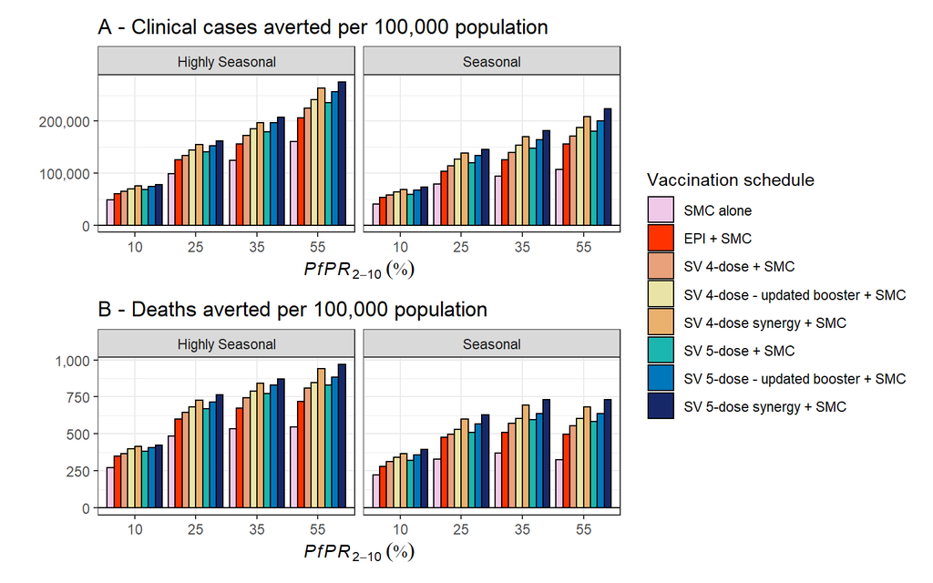

```r
impact <- readRDS('C:/Users/htopazia/OneDrive - Imperial College London/Github/Hayley_report/Part_2/impact_costs_all_ages.RDS')

figure_2_pd <-
  impact %>%
  filter(coverage %in% c(0.8,0), cost_per_dose == 6.52, delivery_cost == 1.62) %>%
  filter(pfpr %in% c(0.1,0.25,0.35,0.55))

# New facet label names for supp variable
seas.labs <- c("Highly Seasonal", "Seasonal")
names(seas.labs) <- c("highly_seasonal", "seasonal")

figure_2_pd$run <- factor(figure_2_pd$run, levels=c("smc", "epi_smc","srtss_4_dose_original_smc", "srtss_4_dose_update_smc",  "srtss_4_dose_param_mod_smc", "srtss_5_dose_original_smc", "srtss_5_dose_update_smc", "srtss_5_dose_param_mod_smc"))

# set the colour levels
color_vals <- c("smc" = "#f0c9e9",
                "epi_smc" = "#FF3200",
                "srtss_4_dose_original_smc" = "#E9A17C",
                "srtss_4_dose_update_smc" = "#E9E4A6",
                "srtss_4_dose_param_mod_smc" = "#eab06d",
                "srtss_5_dose_original_smc" = "#1bb6af",
                "srtss_5_dose_update_smc" = "#0076bb",
                "srtss_5_dose_param_mod_smc" = "#172869")

labels <- c("epi_smc" = "EPI + SMC",
            "srtss_4_dose_original_smc" = "SV 4-dose + SMC",
            "srtss_5_dose_original_smc" = "SV 5-dose + SMC",
            "srtss_4_dose_update_smc" = "SV 4-dose - updated booster + SMC",
            "srtss_5_dose_update_smc" = "SV 5-dose - updated booster + SMC",
            "srtss_4_dose_param_mod_smc" = "SV 4-dose synergy + SMC",
            "srtss_5_dose_param_mod_smc" = "SV 5-dose synergy + SMC",
            "smc" = "SMC alone")

#-plot impact averted-----------------------
ca <-
    ggplot(figure_2_pd, aes(x = factor(pfpr * 100), y = cases_averted, fill=run)) +
    geom_hline(yintercept = 0) +
    geom_bar(position=position_dodge(), stat="identity",colour="black") +
    scale_fill_manual(values = color_vals,
                      labels = labels) +
    labs(x = expression(paste(italic(Pf),"PR"[2-10])),
         y = " ",
         fill="Vaccination schedule",
         parse=TRUE) +
    scale_y_continuous(labels = comma) +
    facet_wrap(seasonality  ~ ., labeller = labeller(seasonality = seas.labs)) +
    xlab(expression(italic(PfPR[2-10]~(symbol("\045"))))) +
    ggtitle("A - Clinical cases averted per 100,000 population") +
    theme_bw( )

da <-
    ggplot(figure_2_pd, aes(x = factor(pfpr * 100), y = deaths_averted, fill=run)) +
    geom_hline(yintercept = 0) +
    geom_bar(position=position_dodge(), stat="identity",colour="black") +
    scale_fill_manual(values = color_vals,
                      labels = labels) +
    labs(x = expression(paste(italic(Pf),"PR"[2-10])),
         y = " ",
         fill="Vaccination schedule",
         parse=TRUE) +
    scale_y_continuous(labels = comma) +
    facet_wrap(seasonality  ~ ., labeller = labeller(seasonality = seas.labs)) +
    xlab(expression(italic(PfPR[2-10]~(symbol("\045"))))) +
    ggtitle("B - Deaths averted per 100,000 population") +
    theme_bw()

report_fig <- ca / da + plot_layout(guides = "collect") & theme(legend.position = "right")

report_fig
```

```r
# ggsave("report_fig_main.png", report_fig)#, width=8, height = 5)
```

## malariasimulation

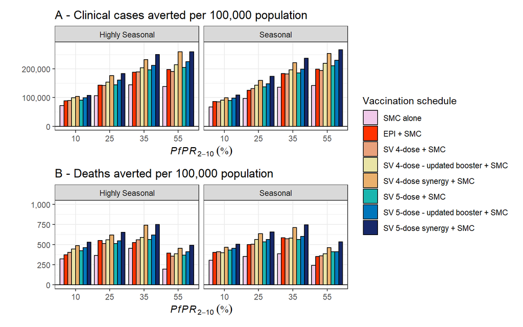

```r
fig2dat <- output %>%
  left_join(match %>% select(pfpr, eir)) %>%
  mutate(pfpr = ifelse(is.na(pfpr), .55, pfpr)) %>%
  filter(grepl('SMC',intervention))

seas.labs <- c("Highly Seasonal", "Seasonal")
names(seas.labs) <- c("highly_seasonal", "seasonal")

# set the colour levels
color_vals <- c("SMC alone" = "#f0c9e9",
                "EPI + SMC" = "#FF3200",
                "SV 4-dose + SMC" = "#E9A17C",
                "SV 4-dose - updated booster + SMC" = "#E9E4A6",
                "SV 4-dose synergy + SMC" = "#eab06d",
                "SV 5-dose + SMC" = "#1bb6af",
                "SV 5-dose - updated booster + SMC" = "#0076bb",
                "SV 5-dose synergy + SMC" = "#172869")

fig2dat$intervention <- factor(fig2dat$intervention, levels=c("SMC alone", "EPI + SMC", "SV 4-dose + SMC", "SV 4-dose - updated booster + SMC", "SV 4-dose synergy + SMC", "SV 5-dose + SMC", "SV 5-dose - updated booster + SMC", "SV 5-dose synergy + SMC"))

labels <- c("SMC alone", "EPI + SMC", "SV 4-dose + SMC", "SV 4-dose - updated booster + SMC", "SV 4-dose synergy + SMC", "SV 5-dose + SMC", "SV 5-dose - updated booster + SMC", "SV 5-dose synergy + SMC")

#-plot impact averted-----------------------
Fig2a <-
    ggplot(fig2dat, aes(x = factor(pfpr * 100), y = cases_averted, fill=intervention)) +
    geom_hline(yintercept = 0) +
    geom_bar(position=position_dodge(), stat="identity",colour="black") +
    scale_fill_manual(values = color_vals,
                      labels = labels) +
    labs(x = expression(paste(italic(Pf),"PR"[2-10])),
         y = " ",
         fill="Vaccination schedule",
         parse=TRUE) +
    facet_wrap(season  ~ ., labeller = labeller(season = seas.labs)) +
    xlab(expression(italic(PfPR[2-10]~(symbol("\045"))))) +
    ggtitle("A - Clinical cases averted per 100,000 population") +
    scale_y_continuous(labels = comma, breaks=seq(0,200000,100000), limits=c(0,280000)) +
    theme_bw( )

Fig2b <-
    ggplot(fig2dat, aes(x = factor(pfpr * 100), y = deaths_averted, fill=intervention)) +
    geom_hline(yintercept = 0) +
    geom_bar(position=position_dodge(), stat="identity",colour="black") +
    scale_fill_manual(values = color_vals,
                      labels = labels) +
    labs(x = expression(paste(italic(Pf),"PR"[2-10])),
         y = " ",
         fill="Vaccination schedule",
         parse=TRUE) +
    facet_wrap(season  ~ ., labeller = labeller(season = seas.labs)) +
    xlab(expression(italic(PfPR[2-10]~(symbol("\045"))))) +
    ggtitle("B - Deaths averted per 100,000 population") +
    scale_y_continuous(labels = comma, breaks=seq(0,1000,250), limits=c(0,1000)) +
    theme_bw()

report_fig <- Fig2a / Fig2b + plot_layout(guides = "collect") & theme(legend.position = "right")

report_fig
```

# Comparison table

Comparing the differences in case and death counts between MalariaLaunchR and malariasimulation outputs, aggregated over 15 years.

- **case difference** = # cases new model - # cases old model
- **case %** = ^ as %
- **death difference** = # deaths new model - # cases deaths model
- **death %** = ^ as %
- **vacc difference** = # vaccinated kids new model - # vaccinated kids old model
- **vacc %** = ^ as %

```r
A <- readRDS('C:/Users/htopazia/OneDrive - Imperial College London/Github/Hayley_report/Part_1/impact_costs_all_ages.RDS')
B <- readRDS('C:/Users/htopazia/OneDrive - Imperial College London/Github/Hayley_report/Part_2/impact_costs_all_ages.RDS')

C <- A %>% full_join(B) %>%
  filter(coverage %in% c(0,0.8), cost_per_dose == 6.52, delivery_cost == 1.62) %>%
  filter(pfpr %in% c(0.1,0.25,0.35,0.55)) %>%
  mutate(intervention = case_when(run=="epi" ~ "EPI",
      run=="srtss_4_dose_original" ~ "SV 4-dose",
      run=="srtss_5_dose_original" ~ "SV 5-dose",
      run=="srtss_4_dose_update" ~ "SV 4-dose - updated booster",
      run=="srtss_5_dose_update" ~ "SV 5-dose - updated booster",
      run=="epi_smc" ~ "EPI + SMC",
      run=="srtss_4_dose_original_smc" ~ "SV 4-dose + SMC",
      run=="srtss_5_dose_original_smc" ~ "SV 5-dose + SMC",
      run=="srtss_4_dose_update_smc" ~ "SV 4-dose - updated booster + SMC",
      run=="srtss_5_dose_update_smc" ~ "SV 5-dose - updated booster + SMC",
      run=="srtss_4_dose_param_mod_smc" ~ "SV 4-dose synergy + SMC",
      run=="srtss_5_dose_param_mod_smc" ~ "SV 5-dose synergy + SMC",
      run=="smc" ~ "SMC alone")) %>%
   select(intervention, pfpr, seasonality, cases, deaths, cases_averted, deaths_averted, cases_averted_per_100000_fvp, number_fvp)

D <- output %>% ungroup() %>%
  left_join(match %>% select(pfpr, eir)) %>%
  mutate(pfpr = ifelse(is.na(pfpr), .55, pfpr)) %>%
  mutate(seasonality = season,
         number_fvp = dosecomplete) %>%
  select(intervention, pfpr, seasonality, cases, deaths, cases_averted, deaths_averted, cases_averted_per_100000_fvp, number_fvp) %>%
  rename(cases2=cases, deaths2=deaths, ca=cases_averted, da=deaths_averted, cafvp=cases_averted_per_100000_fvp, nfvp=number_fvp)

tabledat <- C %>% full_join(D)

tablefun <- function(data, season, title){
  table <- data %>% filter(seasonality==season) %>%
  group_by(intervention, pfpr) %>%
  summarize(case_diff=cases2-cases,
            case_per=case_diff/cases*100,
            deaths_diff=deaths2-deaths,
            deaths_per=deaths_diff/deaths*100,
            nv_diff=nfvp-number_fvp,
            nv_per=nv_diff/number_fvp*100) %>%
  kbl(col.names = c('intervention','PfPR','case difference', 'case %', 'death difference', 'death %', 'vacc difference', 'vacc %'), digits=2, caption = title, escape = F, align = "c") %>%
  kable_styling(bootstrap_options = c("striped", "hover", fixed_thread = T))

  print(table)
}

tablefun(tabledat,'highly_seasonal',"High Seasonality")
```

High Seasonality

| intervention | PfPR | case difference | case % | death difference | death % | vacc difference | vacc % |
| --- | --- | --- | --- | --- | --- | --- | --- |
| EPI | 0.10 | 1994.20 | 0.52 | 72.56 | 5.43 | 12594.56 | 34.68 |
| EPI | 0.25 | -6733.25 | -0.90 | -92.89 | -4.56 | 13140.84 | 36.35 |
| EPI | 0.35 | -5314.99 | -0.59 | -185.53 | -7.84 | 13279.91 | 36.79 |
| EPI | 0.55 | -53546.66 | -4.68 | -696.04 | -24.90 | 12766.16 | 35.27 |
| EPI + SMC | 0.10 | -5099.87 | -1.51 | 107.20 | 9.90 | 13531.13 | 37.41 |
| EPI + SMC | 0.25 | -13595.11 | -2.07 | -55.87 | -3.42 | 13007.16 | 35.85 |
| EPI + SMC | 0.35 | -25445.33 | -3.22 | -107.49 | -5.67 | 13183.64 | 36.40 |
| EPI + SMC | 0.55 | -33770.81 | -3.37 | -451.06 | -19.71 | 13715.76 | 37.93 |
| SMC alone | 0.10 | -686.02 | -0.20 | 80.56 | 6.95 | 0.00 | NaN |
| SMC alone | 0.25 | -3343.00 | -0.49 | 17.44 | 1.00 | 0.00 | NaN |
| SMC alone | 0.35 | -12270.59 | -1.50 | -172.52 | -8.48 | 0.00 | NaN |
| SMC alone | 0.55 | -21032.95 | -2.01 | -427.83 | -17.37 | 0.00 | NaN |
| SV 4-dose | 0.10 | 8295.89 | 2.22 | 98.42 | 7.64 | 5458.18 | 12.32 |
| SV 4-dose | 0.25 | 3946.67 | 0.54 | -43.40 | -2.19 | 5231.27 | 11.81 |
| SV 4-dose | 0.35 | 743.16 | 0.08 | -169.21 | -7.40 | 4974.13 | 11.19 |
| SV 4-dose | 0.55 | -25946.05 | -2.31 | -627.51 | -23.22 | 5305.91 | 11.95 |
| SV 4-dose - updated booster | 0.10 | 16513.00 | 4.53 | 155.18 | 12.50 | 4958.64 | 11.17 |
| SV 4-dose - updated booster | 0.25 | -1000.40 | -0.14 | -56.85 | -2.96 | 4834.33 | 10.90 |
| SV 4-dose - updated booster | 0.35 | 3756.58 | 0.43 | -179.45 | -8.00 | 5271.38 | 11.90 |
| SV 4-dose - updated booster | 0.55 | -32607.71 | -2.97 | -594.43 | -22.52 | 4928.89 | 11.09 |
| SV 4-dose - updated booster + SMC | 0.10 | -7139.84 | -2.17 | 81.91 | 7.91 | 5611.27 | 12.70 |
| SV 4-dose - updated booster + SMC | 0.25 | -5398.67 | -0.85 | 21.09 | 1.36 | 5114.18 | 11.55 |
| SV 4-dose - updated booster + SMC | 0.35 | -12037.54 | -1.58 | -54.84 | -3.08 | 5361.98 | 12.09 |
| SV 4-dose - updated booster + SMC | 0.55 | -15105.84 | -1.56 | -316.34 | -14.63 | 5000.98 | 11.29 |
| SV 4-dose + SMC | 0.10 | -2187.43 | -0.65 | 91.81 | 8.60 | 5245.58 | 11.83 |
| SV 4-dose + SMC | 0.25 | -4462.08 | -0.69 | 33.02 | 2.08 | 5278.80 | 11.88 |
| SV 4-dose + SMC | 0.35 | -10377.90 | -1.34 | -72.46 | -3.97 | 5446.29 | 12.32 |
| SV 4-dose + SMC | 0.55 | -8628.49 | -0.88 | -325.98 | -14.81 | 5534.64 | 12.48 |
| SV 4-dose synergy + SMC | 0.10 | -6766.38 | -2.09 | 57.67 | 5.66 | 5254.89 | 11.83 |
| SV 4-dose synergy + SMC | 0.25 | -16975.09 | -2.71 | 4.00 | 0.27 | 4929.56 | 11.09 |
| SV 4-dose synergy + SMC | 0.35 | -28504.42 | -3.81 | -152.20 | -8.81 | 4950.96 | 11.14 |
| SV 4-dose synergy + SMC | 0.55 | -38252.84 | -4.06 | -288.50 | -13.94 | 5341.38 | 12.03 |
| SV 5-dose | 0.10 | 12218.14 | 3.31 | 84.59 | 6.71 | -2375.33 | -4.57 |
| SV 5-dose | 0.25 | 9779.56 | 1.35 | -62.91 | -3.22 | -2254.22 | -4.34 |
| SV 5-dose | 0.35 | 7981.02 | 0.92 | -176.45 | -7.82 | -2630.53 | -5.08 |
| SV 5-dose | 0.55 | -27289.50 | -2.46 | -608.14 | -22.75 | -2781.78 | -5.33 |
| SV 5-dose - updated booster | 0.10 | 8007.00 | 2.22 | 88.61 | 7.35 | -2373.38 | -4.57 |
| SV 5-dose - updated booster | 0.25 | 3391.24 | 0.48 | -35.50 | -1.89 | -2303.96 | -4.43 |
| SV 5-dose - updated booster | 0.35 | 13353.89 | 1.57 | -134.85 | -6.18 | -2090.62 | -4.03 |
| SV 5-dose - updated booster | 0.55 | -27104.59 | -2.50 | -594.45 | -22.73 | -2567.80 | -4.93 |
| SV 5-dose - updated booster + SMC | 0.10 | -2792.20 | -0.86 | 74.52 | 7.27 | -2795.82 | -5.38 |
| SV 5-dose - updated booster + SMC | 0.25 | -3621.90 | -0.58 | 66.42 | 4.37 | -2290.38 | -4.40 |
| SV 5-dose - updated booster + SMC | 0.35 | -7847.35 | -1.05 | -43.76 | -2.51 | -1997.00 | -3.86 |
| SV 5-dose - updated booster + SMC | 0.55 | -10870.09 | -1.14 | -304.03 | -14.31 | -2424.58 | -4.66 |
| SV 5-dose + SMC | 0.10 | 551.92 | 0.17 | 88.40 | 8.42 | -2340.09 | -4.49 |
| SV 5-dose + SMC | 0.25 | 75.44 | 0.01 | 57.04 | 3.65 | -2178.44 | -4.21 |
| SV 5-dose + SMC | 0.35 | -10139.80 | -1.32 | -46.66 | -2.59 | -2072.96 | -3.99 |
| SV 5-dose + SMC | 0.55 | -12658.98 | -1.30 | -315.23 | -14.47 | -2855.60 | -5.47 |
| SV 5-dose synergy + SMC | 0.10 | -7168.12 | -2.23 | 18.46 | 1.83 | -2508.91 | -4.80 |
| SV 5-dose synergy + SMC | 0.25 | -17783.25 | -2.87 | 8.42 | 0.57 | -2108.84 | -4.07 |
| SV 5-dose synergy + SMC | 0.35 | -35838.16 | -4.85 | -130.84 | -7.71 | -2814.98 | -5.41 |
| SV 5-dose synergy + SMC | 0.55 | -25579.61 | -2.75 | -300.24 | -14.73 | -2560.02 | -4.92 |

```r
tablefun(tabledat,'seasonal',"Low Seasonality")
```

Low Seasonality

| intervention | PfPR | case difference | case % | death difference | death % | vacc difference | vacc % |
| --- | --- | --- | --- | --- | --- | --- | --- |
| EPI | 0.10 | 31777.23 | 8.54 | 110.80 | 8.47 | 12848.93 | 35.49 |
| EPI | 0.25 | -9612.67 | -1.35 | -102.40 | -5.20 | 13118.00 | 36.23 |
| EPI | 0.35 | 14662.11 | 1.72 | -96.88 | -4.32 | 13330.31 | 36.79 |
| EPI | 0.55 | 34496.81 | 3.32 | -441.20 | -17.32 | 12933.67 | 35.75 |
| EPI + SMC | 0.10 | 12846.75 | 3.82 | 49.95 | 4.45 | 13210.47 | 36.45 |
| EPI + SMC | 0.25 | -27652.75 | -4.28 | -78.86 | -4.74 | 13027.89 | 35.97 |
| EPI + SMC | 0.35 | -35932.13 | -4.65 | -242.20 | -12.45 | 13183.53 | 36.33 |
| EPI + SMC | 0.55 | 9687.77 | 1.03 | -339.82 | -15.21 | 13510.40 | 37.63 |
| SMC alone | 0.10 | 19655.56 | 5.63 | 86.99 | 7.36 | 0.00 | NaN |
| SMC alone | 0.25 | -24185.21 | -3.60 | -78.31 | -4.32 | 0.00 | NaN |
| SMC alone | 0.35 | -20624.51 | -2.56 | -186.06 | -8.91 | 0.00 | NaN |
| SMC alone | 0.55 | 16601.20 | 1.68 | -399.57 | -16.60 | 0.00 | NaN |
| SV 4-dose | 0.10 | 42142.32 | 11.49 | 152.34 | 11.87 | 5357.49 | 12.11 |
| SV 4-dose | 0.25 | 7084.14 | 1.01 | -2.14 | -0.11 | 5832.71 | 13.19 |
| SV 4-dose | 0.35 | 19949.31 | 2.39 | -52.61 | -2.40 | 5521.82 | 12.50 |
| SV 4-dose | 0.55 | 58529.25 | 5.74 | -341.49 | -13.80 | 5546.53 | 12.56 |
| SV 4-dose - updated booster | 0.10 | 37893.42 | 10.56 | 150.09 | 12.27 | 4939.29 | 11.13 |
| SV 4-dose - updated booster | 0.25 | -6108.06 | -0.89 | -46.55 | -2.49 | 5128.24 | 11.58 |
| SV 4-dose - updated booster | 0.35 | 22052.39 | 2.69 | -76.00 | -3.54 | 5580.27 | 12.58 |
| SV 4-dose - updated booster | 0.55 | 48810.53 | 4.90 | -327.91 | -13.65 | 5482.13 | 12.42 |
| SV 4-dose - updated booster + SMC | 0.10 | 19508.00 | 5.99 | 116.22 | 10.93 | 5254.96 | 11.84 |
| SV 4-dose - updated booster + SMC | 0.25 | -22792.30 | -3.66 | -89.32 | -5.54 | 5151.56 | 11.58 |
| SV 4-dose - updated booster + SMC | 0.35 | -21210.00 | -2.85 | -146.06 | -7.88 | 5188.69 | 11.66 |
| SV 4-dose - updated booster + SMC | 0.55 | 20750.26 | 2.29 | -264.34 | -12.43 | 5665.49 | 12.84 |
| SV 4-dose + SMC | 0.10 | 19581.96 | 5.91 | 73.43 | 6.72 | 5387.27 | 12.15 |
| SV 4-dose + SMC | 0.25 | -22974.01 | -3.61 | -59.45 | -3.62 | 4918.60 | 11.07 |
| SV 4-dose + SMC | 0.35 | -21333.55 | -2.81 | -173.15 | -9.18 | 5185.00 | 11.68 |
| SV 4-dose + SMC | 0.55 | 28940.12 | 3.13 | -292.77 | -13.44 | 5099.27 | 11.51 |
| SV 4-dose synergy + SMC | 0.10 | 15677.37 | 4.88 | 72.90 | 7.03 | 4838.56 | 10.86 |
| SV 4-dose synergy + SMC | 0.25 | -28461.07 | -4.65 | -89.06 | -5.78 | 5293.80 | 12.02 |
| SV 4-dose synergy + SMC | 0.35 | -30586.54 | -4.19 | -190.25 | -10.78 | 5083.64 | 11.42 |
| SV 4-dose synergy + SMC | 0.55 | 7129.28 | 0.80 | -260.27 | -12.71 | 5115.67 | 11.53 |
| SV 5-dose | 0.10 | 36282.83 | 10.03 | 152.03 | 12.09 | -2387.96 | -4.61 |
| SV 5-dose | 0.25 | -2155.28 | -0.31 | -37.94 | -1.99 | -2054.87 | -3.97 |
| SV 5-dose | 0.35 | 23458.39 | 2.83 | -110.33 | -5.06 | -2583.78 | -4.96 |
| SV 5-dose | 0.55 | 55645.02 | 5.52 | -335.84 | -13.74 | -2159.02 | -4.17 |
| SV 5-dose - updated booster | 0.10 | 34083.03 | 9.68 | 133.29 | 11.07 | -2160.22 | -4.16 |
| SV 5-dose - updated booster | 0.25 | 3686.39 | 0.55 | -16.98 | -0.92 | -2703.89 | -5.20 |
| SV 5-dose - updated booster | 0.35 | 12411.63 | 1.54 | -99.15 | -4.70 | -2484.38 | -4.79 |
| SV 5-dose - updated booster | 0.55 | 50222.70 | 5.09 | -365.84 | -15.27 | -2332.80 | -4.49 |
| SV 5-dose - updated booster + SMC | 0.10 | 15785.57 | 4.89 | 78.43 | 7.51 | -2421.53 | -4.65 |
| SV 5-dose - updated booster + SMC | 0.25 | -19885.12 | -3.23 | -51.66 | -3.28 | -2502.36 | -4.82 |
| SV 5-dose - updated booster + SMC | 0.35 | -12575.60 | -1.71 | -137.07 | -7.52 | -2255.31 | -4.34 |
| SV 5-dose - updated booster + SMC | 0.55 | 22486.35 | 2.51 | -260.81 | -12.45 | -2706.47 | -5.20 |
| SV 5-dose + SMC | 0.10 | 15440.34 | 4.67 | 58.88 | 5.44 | -2299.07 | -4.43 |
| SV 5-dose + SMC | 0.25 | -23213.00 | -3.69 | -80.81 | -4.95 | -2316.36 | -4.46 |
| SV 5-dose + SMC | 0.35 | -17389.82 | -2.32 | -136.66 | -7.34 | -2311.60 | -4.44 |
| SV 5-dose + SMC | 0.55 | 21383.87 | 2.34 | -314.11 | -14.62 | -2550.89 | -4.92 |
| SV 5-dose synergy + SMC | 0.10 | 11127.52 | 3.52 | 64.45 | 6.39 | -2509.42 | -4.82 |
| SV 5-dose synergy + SMC | 0.25 | -35808.85 | -5.92 | -81.15 | -5.37 | -2323.78 | -4.47 |
| SV 5-dose synergy + SMC | 0.35 | -33548.70 | -4.68 | -187.87 | -10.88 | -2503.64 | -4.81 |
| SV 5-dose synergy + SMC | 0.55 | 10163.50 | 1.17 | -283.68 | -14.19 | -2575.91 | -4.95 |

# Seasonality

Hayley’s report says the interventions should be given out ‘in the three months preceding the transmission season’. It appears that this is month 4 for seasonal settings and month 6 for highly seasonal settings.

For `malariasimulation` RTS,S dose #3 efficacy starts at month 4 for seasonal settings and month 6 for highly seasonal settings. SMC rounds are spaced so that it covers the high transmission season. RTS,S is shown in blue and SMC in red below.

## malariasimulation

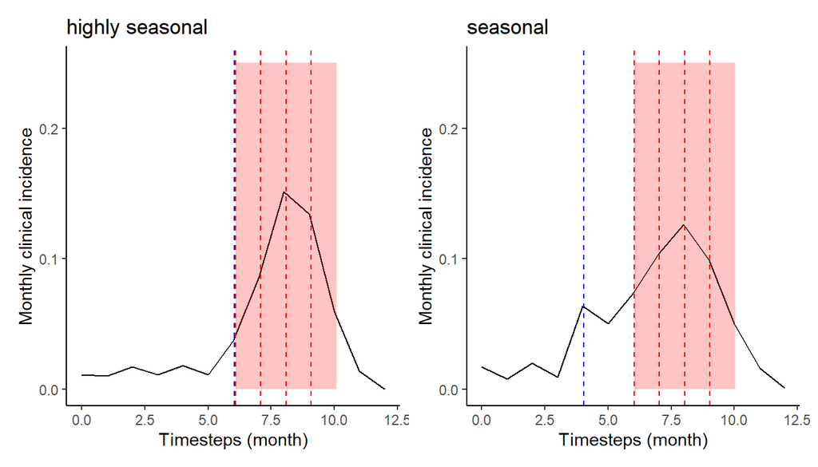

```r
human_population <- 1000
year <- 365
month <- year/12
warmup <- 4*year
sim_length <- 1*year

# highly seasonal parameters
high_seas <- get_parameters(list(
  human_population = human_population,
  model_seasonality = TRUE,
  g0 = 0.284596,
  g = c(-0.317878, -0.0017527, 0.116455),
  h = c(-0.331361, 0.293128, -0.0617547),
  incidence_rendering_min_ages = 0,
  incidence_rendering_max_ages = 100 * year,
  clinical_incidence_rendering_min_ages = 0,
  clinical_incidence_rendering_max_ages = 100 * year,
  fvt = 0,
  v = 0,
  severe_enabled = T))

# seasonal parameters
low_seas <- get_parameters(list(
  human_population = human_population,
  model_seasonality = TRUE,
  g0 = 0.285505,
  g = c(-0.325352, -0.0109352, 0.0779865),
  h = c(-0.132815, 0.104675, -0.013919),
  incidence_rendering_min_ages = 0,
  incidence_rendering_max_ages = 100 * year,
  clinical_incidence_rendering_min_ages = 0,
  clinical_incidence_rendering_max_ages = 100 * year,
  fvt = 0,
  v = 0,
  severe_enabled = T))

# run model
params <- high_seas
params <- set_equilibrium(params, 10)
output_highseas <- run_simulation(warmup + sim_length, params)

params <- low_seas
params <- set_equilibrium(params, 10)
output_lowseas <- run_simulation(warmup + sim_length, params)

plotfun <- function(data,title){
  data %>%
  mutate(timestep = timestep - warmup) %>% filter(timestep > 0) %>%
  mutate(month=floor(timestep/(365/12))) %>%
  group_by(month) %>%
  summarize(inc_month=sum(n_inc_clinical_0_36500 / n_0_36500, na.rm=T)) %>%
ggplot() +
  geom_line(aes(x=month, y=inc_month)) +
  labs(title=title,
       x="Timesteps (month)",
       y="Monthly clinical incidence") +
  scale_y_continuous(limits=c(0,0.25),breaks=c(0,0.1,0.2)) +
  theme_classic()
}

first_highseas <- c((peak_season_offset(high_seas)/month) + c(-1.55,-1.5,-0.5,0.5,1.5)) %>%
  as_tibble() %>%
  mutate(color = c(rep('blue',1), rep('red',4)),
         type = c(rep('RTS,S',1), rep('SMC',4)))

first_lowseas <- c((peak_season_offset(low_seas)/month) + c(-3.5,-1.5,-0.5,0.5,1.5)) %>%
  as_tibble() %>%
  mutate(color = c(rep('blue',1), rep('red',4)),
         type = c(rep('RTS,S',1), rep('SMC',4)))

A <- plotfun(output_highseas,"highly seasonal") +
  geom_vline(xintercept=first_highseas$value, lty=2, color=first_highseas$color) +
  geom_rect(xmin = 6.094521, xmax = 9.094521 + 1, ymin = 0, ymax = 0.25, fill="red", alpha = 0.02)

B <- plotfun(output_lowseas,"seasonal") +
  geom_vline(xintercept=first_lowseas$value, lty=2, color=first_lowseas$color) +
  geom_rect(xmin = 6.028767, xmax = 9.028767 + 1, ymin = 0, ymax = 0.25, fill="red", alpha = 0.02)

A + B
```

# Baseline comparison

Now we will directly compare model outputs from `malariasimulation` to `MalariaLaunchR`.

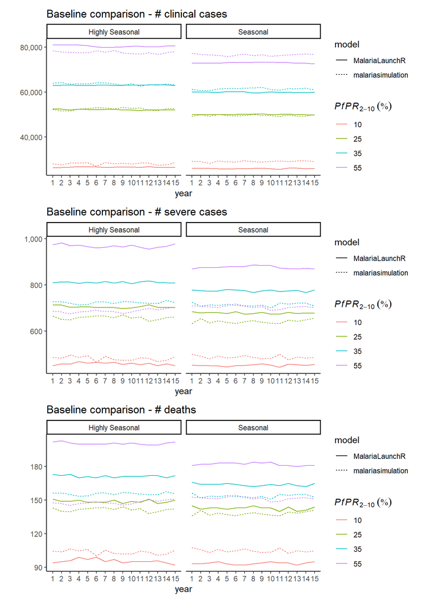

```r
#-New facet label names for seas variables--
seas.labs <- c("Highly Seasonal", "Seasonal")
names(seas.labs) <- c("highly_seasonal", "seasonal")

population_size = 100000 #target outputs per 100,000 population size
tx = 0.52                #treatment coverage run in simulations
scaler = 0.215           #severe case to death modifier
treatment_scaler = 0.5   #treatment modifier
treatment_coverage = 0.52#coverage

oldmodelprocess <- function(file){readRDS(file) %>%
  dplyr::select(-contains("prev_2_10")) %>%
  mutate_at(vars(contains("smooth")), as.numeric) %>%
  # keep smoothed output and ignore intervention numbers for now
  dplyr::select(run, pfpr, seasonality, draw, coverage, year, dplyr::contains("smooth")) %>%
  #-convert from wide to long format
  tidyr::pivot_longer(-c(year, run, pfpr, seasonality, draw, coverage), names_to = "var", values_to = "y") %>%
  #-remove _smooth subscript for neater names
  dplyr::mutate(var = stringr::str_remove(var, "_smooth")) %>%
  #-isolate lower and upper age bounds from variable names
  tidyr::separate(var, into = c("type", "age_lower", "age_upper"), sep = "_", convert = TRUE) %>%
  #-convert back to wide
  tidyr::pivot_wider(id_cols = c(run, pfpr, seasonality, draw, coverage, year, age_lower, age_upper), names_from = type, values_from = y) %>%
  #-replace -999 / INF/ NA values in output
  dplyr::mutate(prev = ifelse(prev == -999, 0, prev),
                inc = ifelse(inc == -999, 0, inc),
                inc = ifelse(inc == Inf, 0, inc),
                sev = ifelse(sev == -999, 0, sev),
                sev = ifelse(sev == Inf, 0, sev),
                prop = ifelse(prop == -999, 0, prop)) %>%
  tidyr::replace_na(
    list( prev = 0, inc = 0, sev = 0, prop = 0)) %>%
  #-mortality rate
  mutate(mort = (1-(treatment_scaler * 0)) * scaler * sev) %>%
  #-convert burden (incidence * proportion aged * population size)
  #-case load is weighted by proportion in age range in population * total size
  mutate(cases            = round(inc * prop * population_size),
         severe           = round(sev * prop * population_size),
         hospitalisations = round(severe * tx),
         deaths           = round(mort * prop * population_size)) %>%
  filter(year > 0) %>%
  filter(coverage %in% c(0.8,0)) %>%
  group_by(run, pfpr, seasonality, coverage, draw, year) %>%
  summarise(across(cases:deaths, sum)) %>%
  ungroup() %>% mutate(model='MalariaLaunchR') %>% filter(pfpr %in% c(0.1,0.25,0.35,0.55))
}

baselineA <- oldmodelprocess('C:/Users/htopazia/OneDrive - Imperial College London/Github/Hayley_report/Part_1/combined_outputs_raw.RDS') %>%
  rbind(oldmodelprocess('C:/Users/htopazia/OneDrive - Imperial College London/Github/Hayley_report/Part_2/combined_outputs_smc.RDS')) %>% distinct()

# malariasimulation
baselineB <- readRDS("C:/Users/htopazia/OneDrive - Imperial College London/Github/rtss_malariasimulation/rds/rtss_smc_all.rds") %>%
  mutate(year=ceiling(timestep/365)) %>%
  rename(seasonality=season) %>%
  group_by(intervention, eir, seasonality, year) %>%
  summarize(cases = sum(cases, na.rm=T),
            severe = sum(severe_p, na.rm=T),
            deaths = sum(deaths_p, na.rm=T),
            model='malariasimulation') %>% ungroup() %>%
  left_join(match %>% select(pfpr, eir, seasonality))

data <- baselineA %>% filter(run == "baseline") %>% full_join(baselineB %>% filter(intervention == 'none'))

# plots
plotbaseline <- function(data, var, title){
ggplot(data=data, aes(x=year, y=var, color=factor(pfpr * 100), lty=model)) +
  geom_line() +
  labs(x = expression(paste(italic(Pf),"PR"[2-10])),
       y = " ",
       parse=TRUE) +
  scale_y_continuous(labels = comma) +
  scale_x_continuous(breaks = seq(1,15,1)) +
  facet_wrap(seasonality  ~ ., labeller = labeller(seasonality = seas.labs)) +
  labs(x='year', color=expression(italic(PfPR[2-10]~(symbol("\045"))))) +
  ggtitle(title) +
  theme_classic()
}

plotcompare <- function(data, title){
plotbaseline(data, data$cases, paste(title,"comparison - # clinical cases")) /
plotbaseline(data, data$severe, paste(title,"comparison - # severe cases")) /
plotbaseline(data, data$deaths, paste(title,"comparison - # deaths"))
}

plotcompare(data, "Baseline")
```

# Intervention comparison

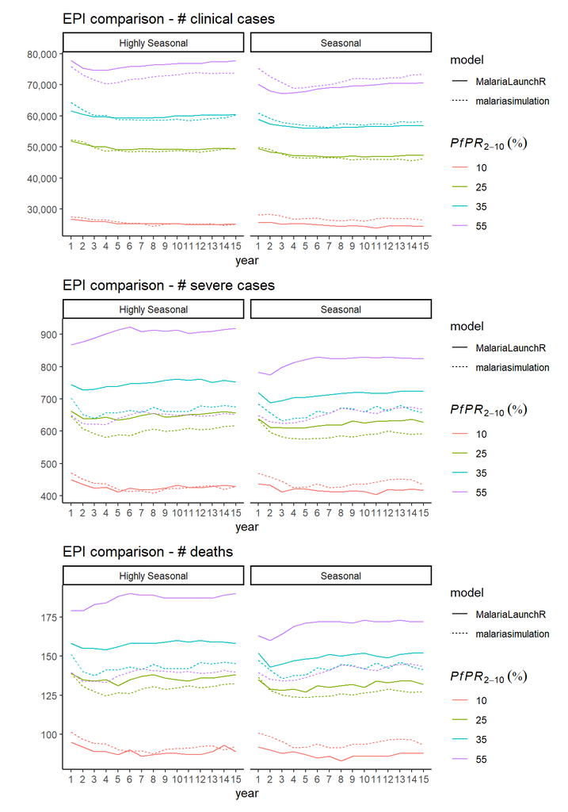

```r
data <- baselineA %>% filter(run == "epi") %>% full_join(baselineB %>% filter(intervention == 'EPI'))
plotcompare(data, "EPI")
```

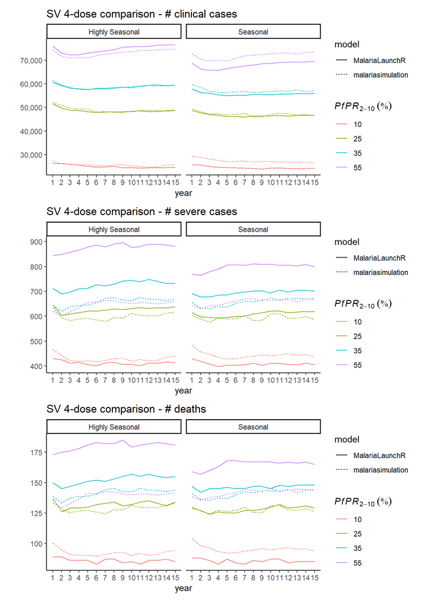

```r
data <- baselineA %>% filter(run == "srtss_4_dose_original") %>% full_join(baselineB %>% filter(intervention == 'SV 4-dose'))
plotcompare(data, "SV 4-dose")
```

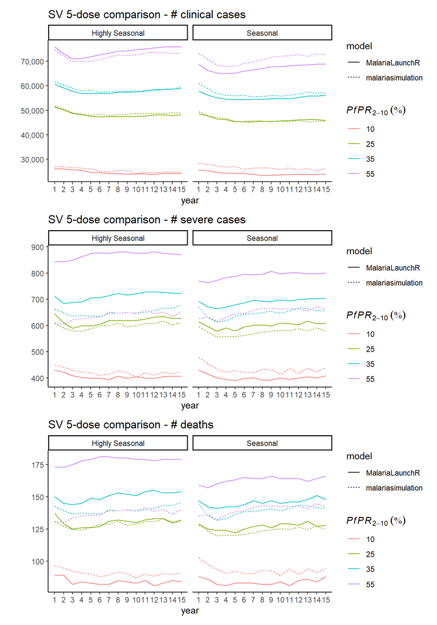

```r
data <- baselineA %>% filter(run == "srtss_5_dose_original") %>% full_join(baselineB %>% filter(intervention == 'SV 5-dose'))
plotcompare(data, "SV 5-dose")
```

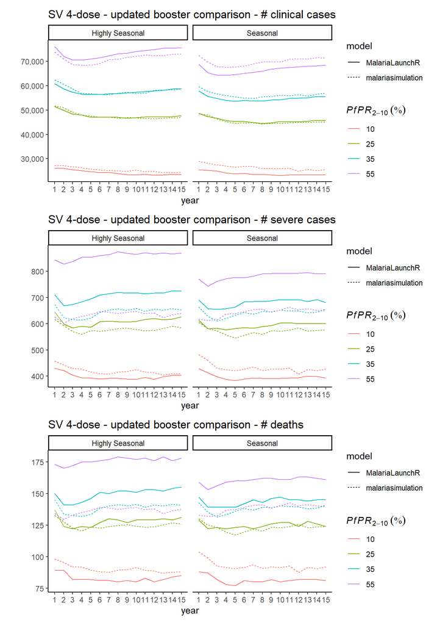

```r
data <- baselineA %>% filter(run == "srtss_4_dose_update") %>% full_join(baselineB %>% filter(intervention == 'SV 4-dose - updated booster'))
plotcompare(data, "SV 4-dose - updated booster")
```

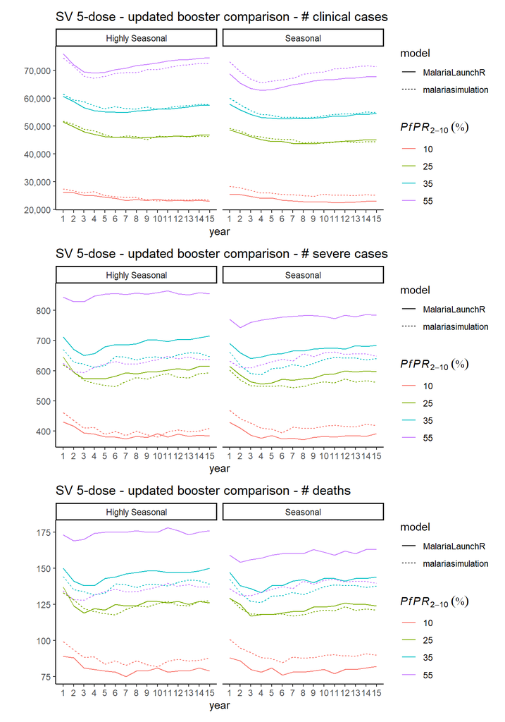

```r
data <- baselineA %>% filter(run == "srtss_5_dose_update") %>% full_join(baselineB %>% filter(intervention == 'SV 5-dose - updated booster'))
plotcompare(data, "SV 5-dose - updated booster")
```

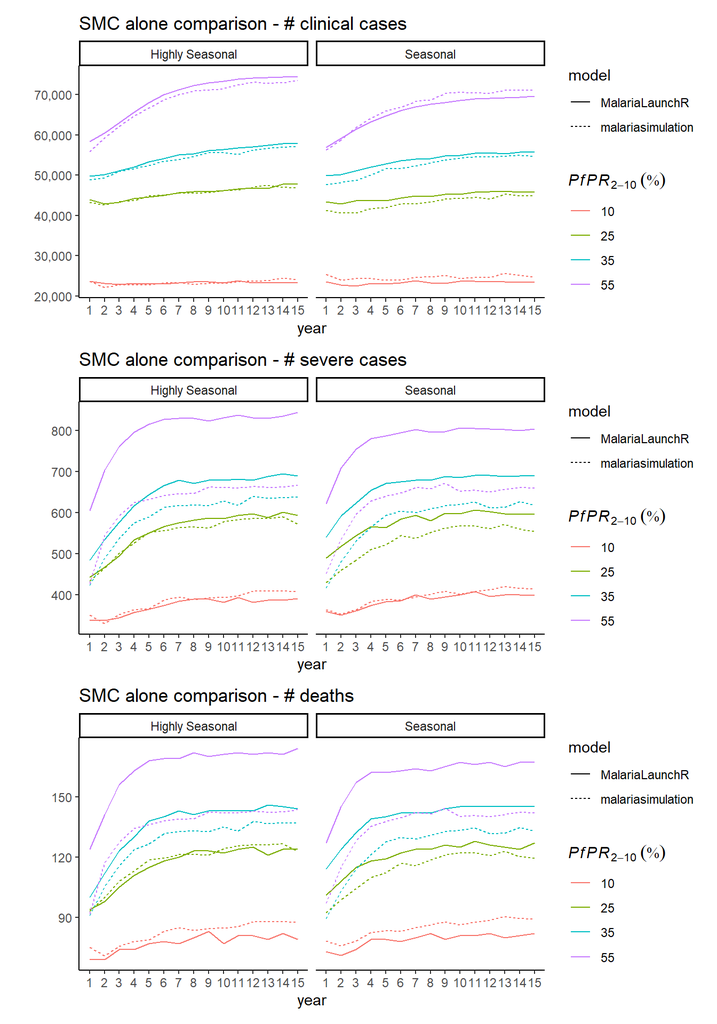

```r
data <- baselineA %>% filter(run == "smc") %>% full_join(baselineB %>% filter(intervention == 'SMC alone'))
plotcompare(data, "SMC alone")
```

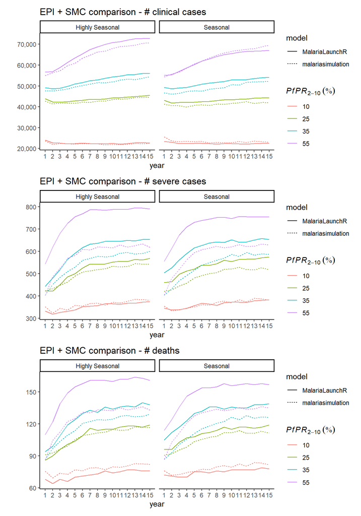

```r
data <- baselineA %>% filter(run == "epi_smc") %>% full_join(baselineB %>% filter(intervention == 'EPI + SMC'))
plotcompare(data, "EPI + SMC")
```

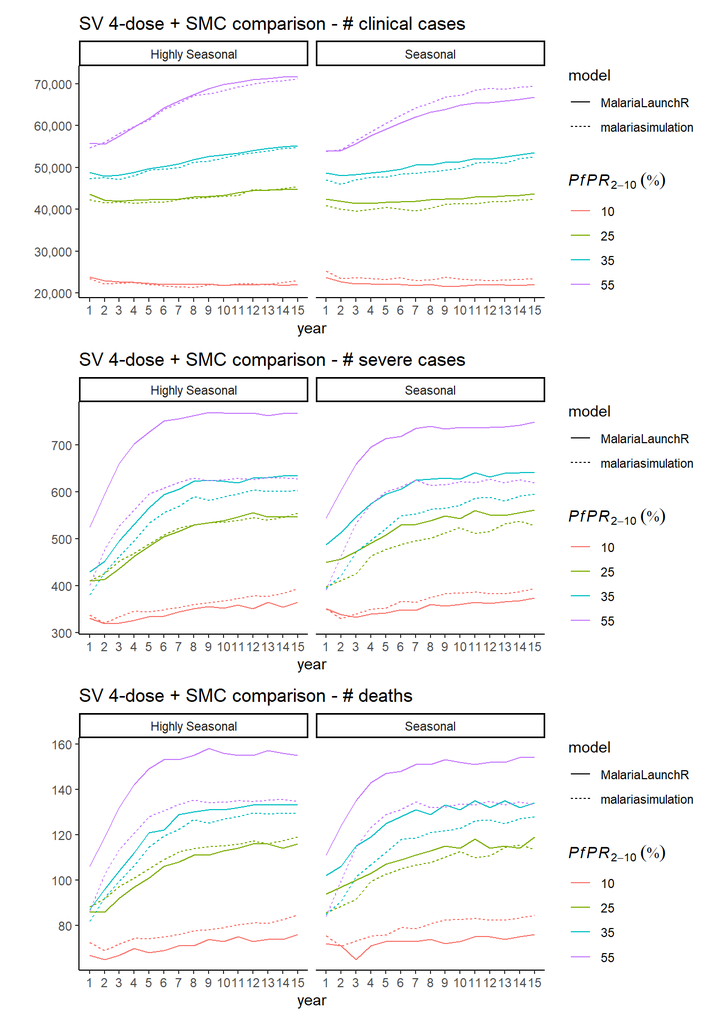

```r
data <- baselineA %>% filter(run == "srtss_4_dose_original_smc") %>% full_join(baselineB %>% filter(intervention == 'SV 4-dose + SMC'))
plotcompare(data, "SV 4-dose + SMC")
```

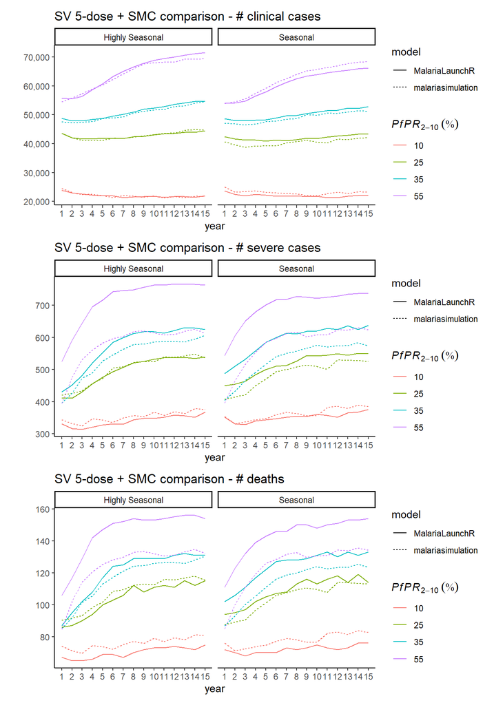

```r
data <- baselineA %>% filter(run == "srtss_5_dose_original_smc") %>% full_join(baselineB %>% filter(intervention == 'SV 5-dose + SMC'))
plotcompare(data, "SV 5-dose + SMC")
```

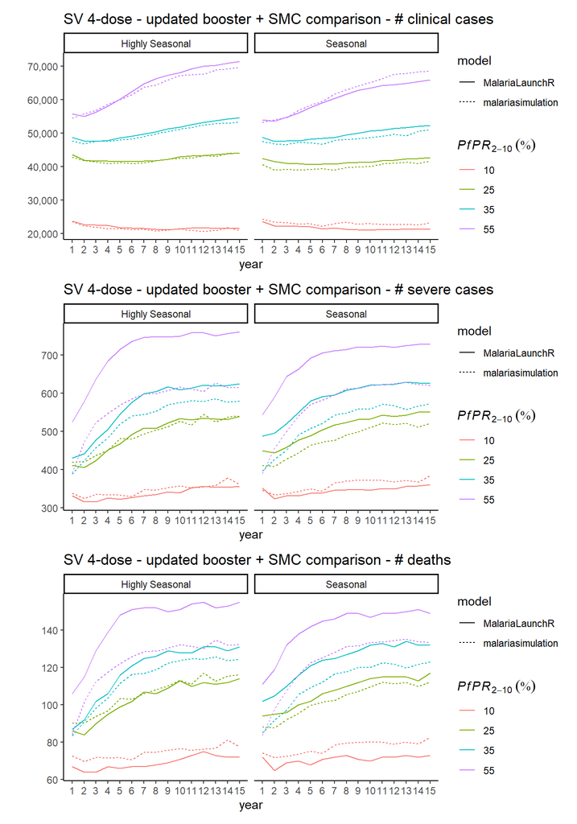

```r
data <- baselineA %>% filter(run == "srtss_4_dose_update_smc") %>% full_join(baselineB %>% filter(intervention == 'SV 4-dose - updated booster + SMC'))
plotcompare(data, "SV 4-dose - updated booster + SMC")
```

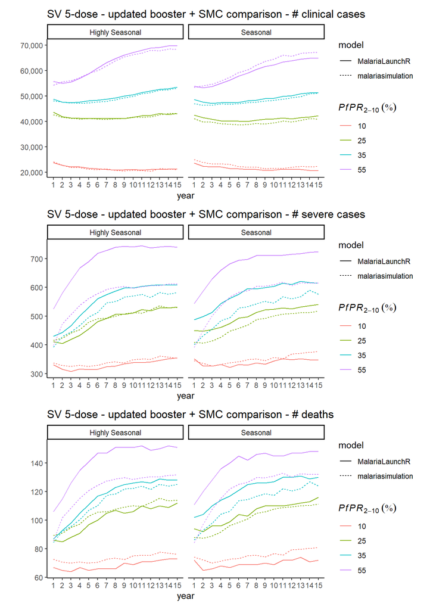

```r
data <- baselineA %>% filter(run == "srtss_5_dose_update_smc") %>% full_join(baselineB %>% filter(intervention == 'SV 5-dose - updated booster + SMC'))
plotcompare(data, "SV 5-dose - updated booster + SMC")
```

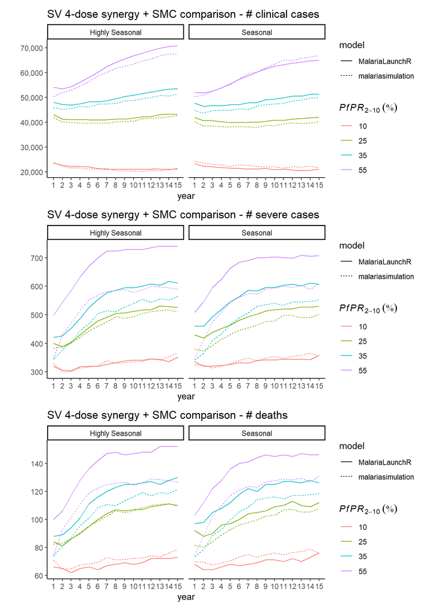

```r
data <- baselineA %>% filter(run == "srtss_4_dose_param_mod_smc") %>% full_join(baselineB %>% filter(intervention == 'SV 4-dose synergy + SMC'))
plotcompare(data, "SV 4-dose synergy + SMC")
```

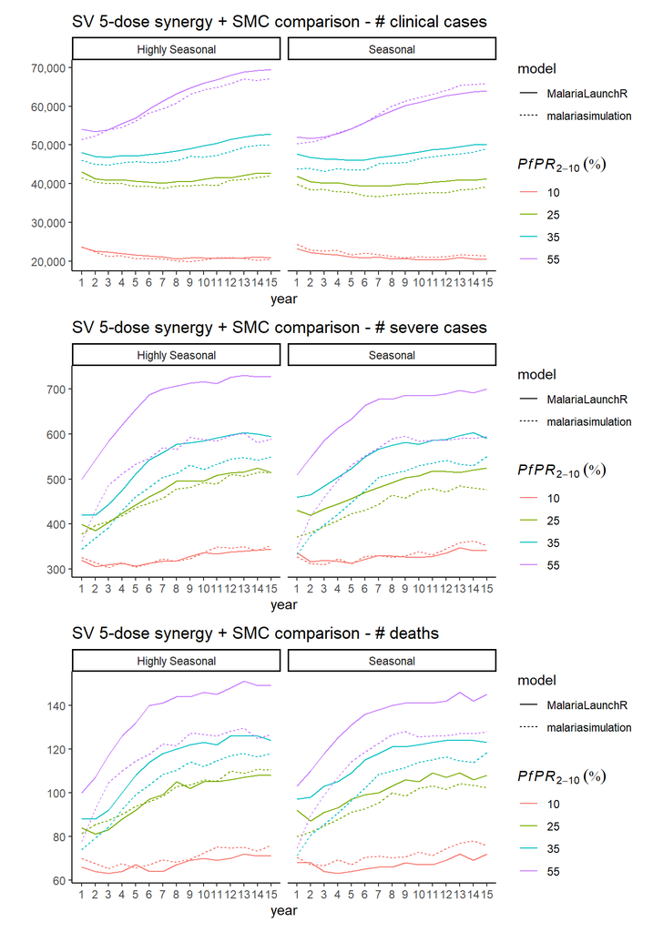

```r
data <- baselineA %>% filter(run == "srtss_5_dose_param_mod_smc") %>% full_join(baselineB %>% filter(intervention == 'SV 5-dose synergy + SMC'))
plotcompare(data, "SV 5-dose synergy + SMC")
```

# Vaccine comparison

Hayley is calculating this here: https://github.com/htopazian/seasonal_use_case/blob/main/Part_1/4_post_processing.R#L125-L149. I’m not sure if the code is correctly adjusting back to dose 3 for scenarios where children receive 1 booster (EPI and SV 4-dose). The number of children receiving dose 3 should be the same under all booster scenarios.

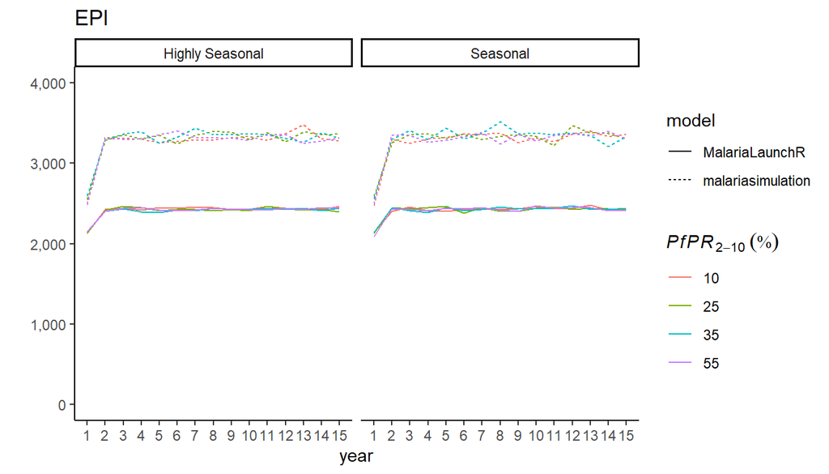

```r
dose_scaler <- 0.266666667 #total doses need to get scaled to number fully vaccinated children (first 3 doses)

vaccineA <- readRDS('C:/Users/htopazia/OneDrive - Imperial College London/Github/Hayley_report/Part_1/combined_outputs_raw.RDS') %>%
  rbind(readRDS('C:/Users/htopazia/OneDrive - Imperial College London/Github/Hayley_report/Part_2/combined_outputs_smc.RDS')) %>% distinct() %>%
  group_by(run, pfpr, seasonality, draw, coverage) %>%
  dplyr::mutate(
    num_vacc_doses = c(0, diff(num_vacc_doses / 3)),
    num_trt        = c(0, diff(num_trt /3))) %>%
   select(run, pfpr, seasonality, draw, coverage, year, num_vacc_doses,  num_trt) %>%
  filter(year > 0) %>%
  filter(coverage %in% c(0.8,0)) %>%
  filter(pfpr %in% c(0.1,0.25,0.35,0.55)) %>%
  mutate(model='MalariaLaunchR',
         dose3=num_vacc_doses * dose_scaler) %>%
  mutate(intervention = case_when(run=="epi" ~ "EPI",
      run=="srtss_4_dose_original" ~ "SV 4-dose",
      run=="srtss_5_dose_original" ~ "SV 5-dose",
      run=="srtss_4_dose_update" ~ "SV 4-dose - updated booster",
      run=="srtss_5_dose_update" ~ "SV 5-dose - updated booster",
      run=="epi_smc" ~ "EPI + SMC",
      run=="srtss_4_dose_original_smc" ~ "SV 4-dose + SMC",
      run=="srtss_5_dose_original_smc" ~ "SV 5-dose + SMC",
      run=="srtss_4_dose_update_smc" ~ "SV 4-dose - updated booster + SMC",
      run=="srtss_5_dose_update_smc" ~ "SV 5-dose - updated booster + SMC",
      run=="srtss_4_dose_param_mod_smc" ~ "SV 4-dose synergy + SMC",
      run=="srtss_5_dose_param_mod_smc" ~ "SV 5-dose synergy + SMC",
      run=="smc" ~ "SMC alone"))

# malariasimulation
vaccineB <- readRDS("C:/Users/htopazia/OneDrive - Imperial College London/Github/rtss_malariasimulation/rds/rtss_smc_all.rds") %>%
  mutate(year=ceiling(timestep/365)) %>%
  rename(seasonality=season) %>%
  group_by(intervention, eir, seasonality, year) %>%
  summarize(dose3 = sum(dose3, na.rm=T),
            model='malariasimulation') %>%
  left_join(match %>% select(pfpr, eir)) %>%
  mutate(pfpr = ifelse(is.na(pfpr), .55, pfpr))

# plots
plotvaccine <- function(data, title){
ggplot(data=data, aes(x=year, y=dose3, color=factor(pfpr * 100), lty=model)) +
  geom_line() +
  labs(x = expression(paste(italic(Pf),"PR"[2-10])),
       y = " ",
       parse=TRUE) +
  scale_y_continuous(labels = comma, limits = c(0,4000), breaks = seq(0,4000,1000)) +
  scale_x_continuous(breaks = seq(1,15,1)) +
  facet_wrap(seasonality  ~ ., labeller = labeller(seasonality = seas.labs)) +
  labs(x='year', color=expression(italic(PfPR[2-10]~(symbol("\045"))))) +
  ggtitle(title) +
  theme_classic()
}

vaxdat <- vaccineA %>% full_join(vaccineB)

plotvaccine(vaxdat %>% filter(intervention == "EPI"), "EPI")
```

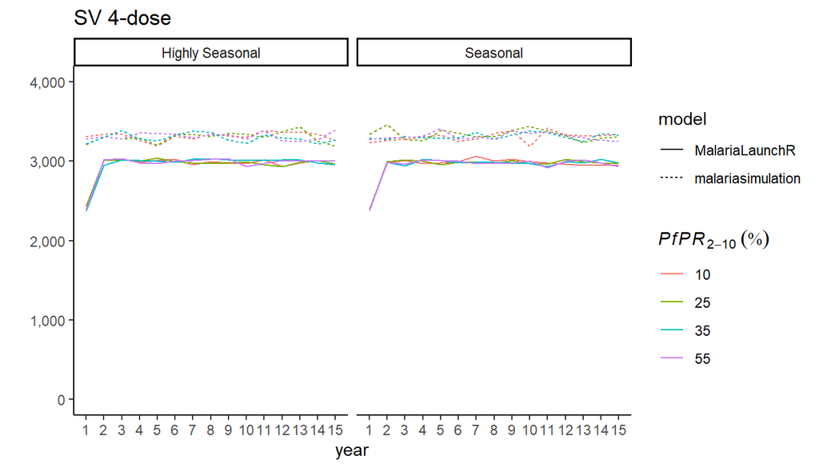

```r
plotvaccine(vaxdat %>% filter(intervention == "SV 4-dose"), "SV 4-dose")
```

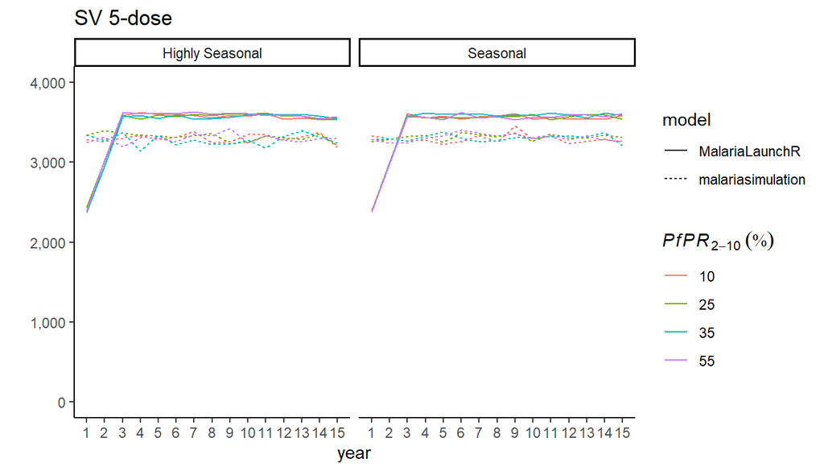

```r
plotvaccine(vaxdat %>% filter(intervention == "SV 5-dose"), "SV 5-dose")
```

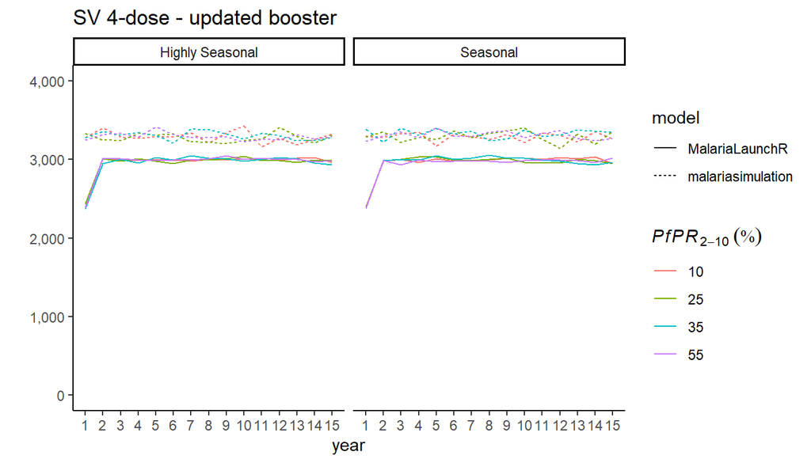

```r
plotvaccine(vaxdat %>% filter(intervention == "SV 4-dose - updated booster"), "SV 4-dose - updated booster")
```

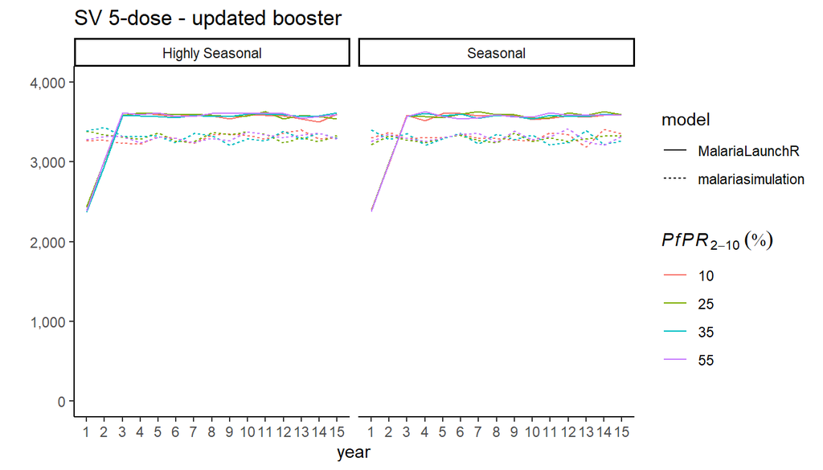

```r
plotvaccine(vaxdat %>% filter(intervention == "SV 5-dose - updated booster"), "SV 5-dose - updated booster")
```

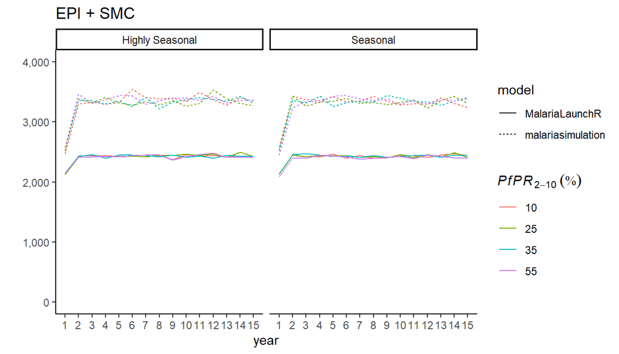

```r
plotvaccine(vaxdat %>% filter(intervention == "EPI + SMC"), "EPI + SMC")
```

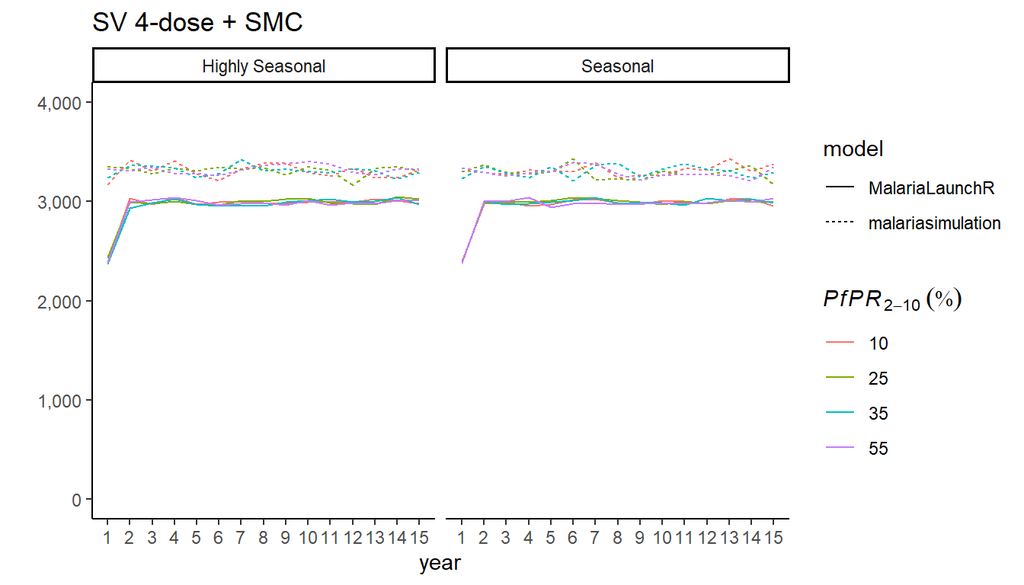

```r
plotvaccine(vaxdat %>% filter(intervention == "SV 4-dose + SMC"), "SV 4-dose + SMC")
```

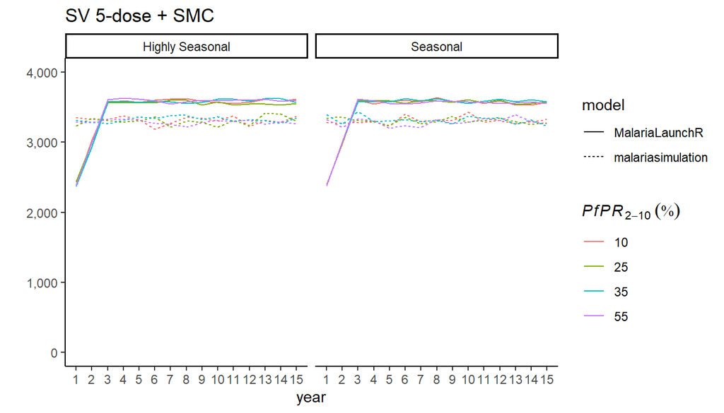

```r
plotvaccine(vaxdat %>% filter(intervention == "SV 5-dose + SMC"), "SV 5-dose + SMC")
```

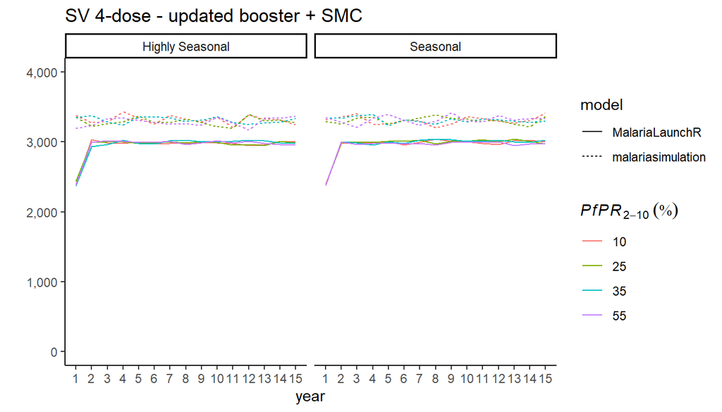

```r
plotvaccine(vaxdat %>% filter(intervention == "SV 4-dose - updated booster + SMC"), "SV 4-dose - updated booster + SMC")
```

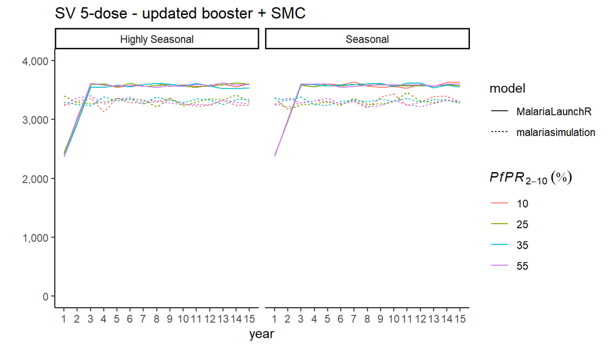

```r
plotvaccine(vaxdat %>% filter(intervention == "SV 5-dose - updated booster + SMC"), "SV 5-dose - updated booster + SMC")
```

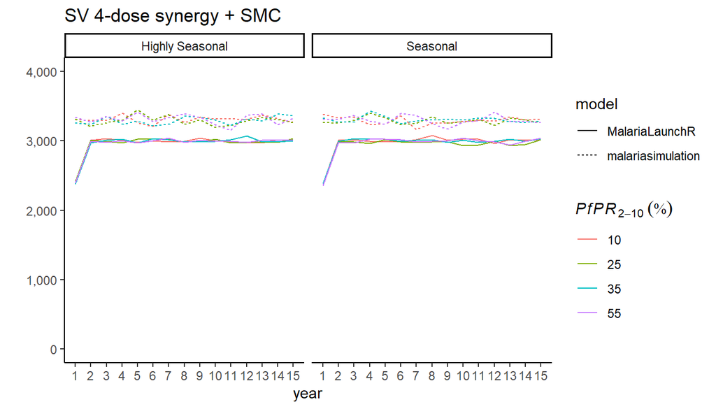

```r
plotvaccine(vaxdat %>% filter(intervention == "SV 4-dose synergy + SMC"), "SV 4-dose synergy + SMC")
```

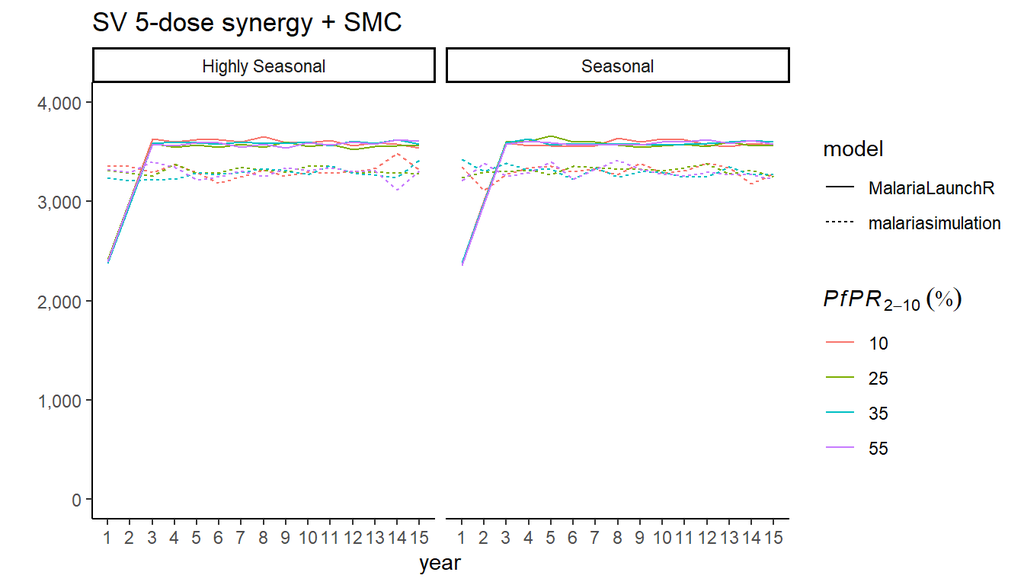

```r
plotvaccine(vaxdat %>% filter(intervention == "SV 5-dose synergy + SMC"), "SV 5-dose synergy + SMC")
```

# Age group comparison

`malariaEquilibrium` uses the average age to calculate an exponential demography. This does not match up with the `mlgts::flat_demog` file Hayley used. I am including a code snippet from [malariaEquilibrium](https://github.com/mrc-ide/malariaEquilibrium/blob/b331dab66cac15a8e0ec91171265877f6de92b09/R/main.R#L58-L90), but it does not appear to be working …

```r
# load mlgts demography file
load("C:/Users/htopazia/OneDrive - Imperial College London/Github/rtss_malariasimulation/flat_demog.rda")

flat_demog %>% rename(year = V1, age_lower = V2, age_upper = V3, inflow = V4, outflow = V5)
```

```
##    year  age_lower  age_upper   inflow   outflow
## 1  2010  0.0000000   0.083333 0.040481 0.4014834
## 2  2010  0.0833333   1.000000 0.040481 0.0583379
## 3  2010  1.0000000   5.000000 0.040481 0.0380348
## 4  2010  5.0000000  10.000000 0.040481 0.0395061
## 5  2010 10.0000000  15.000000 0.040481 0.0347255
## 6  2010 15.0000000  20.000000 0.040481 0.0240849
## 7  2010 20.0000000  25.000000 0.040481 0.0300902
## 8  2010 25.0000000  30.000000 0.040481 0.0357914
## 9  2010 30.0000000  35.000000 0.040481 0.0443123
## 10 2010 35.0000000  40.000000 0.040481 0.0604932
## 11 2010 40.0000000  45.000000 0.040481 0.0466799
## 12 2010 45.0000000  50.000000 0.040481 0.0426199
## 13 2010 50.0000000  55.000000 0.040481 0.0268332
## 14 2010 55.0000000  60.000000 0.040481 0.0493610
## 15 2010 60.0000000  65.000000 0.040481 0.0234852
## 16 2010 65.0000000  70.000000 0.040481 0.0988317
## 17 2010 70.0000000  75.000000 0.040481 0.0467550
## 18 2010 75.0000000  80.000000 0.040481 0.1638875
## 19 2010 80.0000000  85.000000 0.040481 0.1148753
## 20 2010 85.0000000  90.000000 0.040481 0.3409079
## 21 2010 90.0000000  95.000000 0.040481 0.2239224
## 22 2010 95.0000000 200.000000 0.040481 0.8338688
```

```r
# get basic properties
age <- c(0,0.083333,1,seq(5,95,5),200)
av_age <- 8453.323/365
eta <- 1/av_age # should this be 1/average life expectancy?
n_age <- length(age)
age_days <- age*365

# produce population age distribution using eta, which is defined as 1/average
# age. The population distribution can be envisioned as an exponential
# distribution, with mass feeding in from the left due to birth at rate eta,
# people ageing with rates defined based on the width of the age groups, and
# mass leaking out of all categories with death rate eta. Total birth and
# death rates are equal, making the distribution stable.
prop <- r <- rep(0, n_age)
for (i in 1:n_age) {

# r[i] can be thought of as the rate of ageing in this age group, i.e.
# 1/r[i] is the duration of this group
if (i == n_age) {
  r[i] <- 0
} else {
  age_width <- age_days[i+1] - age_days[i]
  r[i] <- 1/age_width
}
# prop is calculated from the relative flows into vs. out of this age group.
# For the first age group the flow in is equal to the birth rate (eta). For
# all subsequent age groups the flow in represents ageing from the previous
# group. The flow out is always equal to the rate of ageing or death.
if (i == 1) {
      prop[i] <- eta/(r[i] + eta)
} else {
  prop[i] <- prop[i-1]*r[i-1]/(r[i] + eta)
  }
}

cbind(age,r,prop)
```

```
##              age            r         prop
##  [1,]   0.000000 3.287684e-02 5.677235e-01
##  [2,]   0.083333 2.988791e-03 4.042915e-01
##  [3,]   1.000000 6.849315e-04 2.754797e-02
##  [4,]   5.000000 5.479452e-04 4.315139e-04
##  [5,]  10.000000 5.479452e-04 5.407417e-06
##  [6,]  15.000000 5.479452e-04 6.776180e-08
##  [7,]  20.000000 5.479452e-04 8.491414e-10
##  [8,]  25.000000 5.479452e-04 1.064082e-11
##  [9,]  30.000000 5.479452e-04 1.333430e-13
## [10,]  35.000000 5.479452e-04 1.670957e-15
## [11,]  40.000000 5.479452e-04 2.093921e-17
## [12,]  45.000000 5.479452e-04 2.623949e-19
## [13,]  50.000000 5.479452e-04 3.288142e-21
## [14,]  55.000000 5.479452e-04 4.120459e-23
## [15,]  60.000000 5.479452e-04 5.163458e-25
## [16,]  65.000000 5.479452e-04 6.470469e-27
## [17,]  70.000000 5.479452e-04 8.108319e-29
## [18,]  75.000000 5.479452e-04 1.016075e-30
## [19,]  80.000000 5.479452e-04 1.273271e-32
## [20,]  85.000000 5.479452e-04 1.595571e-34
## [21,]  90.000000 5.479452e-04 1.999453e-36
## [22,]  95.000000 2.609263e-05 2.535832e-38
## [23,] 200.000000 0.000000e+00 1.532403e-41
```

# Things to check

- MalariaLaunchR uses a constant population size and demography based on the life table for Butajira, Ethiopia, with an average life expectancy at birth of 46.6 years. Test malariasimulation with the flat_demog.txt file when the model can handle demography inputs.
- Report states that ‘events averted are presented as the cumulative number of events averted over a 15-year period following the introduction of vaccine dose 3.’ In malariasimulation I am summing events over the entire 15-year simulation length.
- SMC rounds - the old model runs 3 rounds, but it was supposed to be 4, Hayley will send an updated rds file.